# KPP Stem Tracking : Progress 27 May 2014

JH MC, TB - TLL C - Calibre ML - SWI GS, TH, NM - Tui

## Aims

- determine what is causing the partially poor correlation between stem velocity and average log velocity and fix it
- understand the log tool 'night shift' issue and fix it
- understand when a stem will be matched via stemNumber to a good USNR image file

## Things Done or In Progress

- Calibre PC being unplugged. FIXED. Power to PC hardwired.
- Primary pneumatic actuator performance sensitive to air temperature. Failing to perform properly at night when the temperature low. FIXED 2/4/14. Actuator now being heated with electric coil. Further improvements will include dynamically adjusting timing parameters based on actual actuator performance. UPDATE 23/5/2014: The mic failed and the tool was down for a few weeks. It has now been repaired and upgraded (see chung email)
- Stem sonic tool vs hitman. 10/3/2014. See separate report.
- GS/TH made changes to the code that operates on stem sonic info coming from foxtrot and inserts stem velocity into the SWIPC database
- Stem velocity written to SWIPC not matching the velocity written to Foxtrot log file (WeekNN_YY.txt). PARTIALLY FIXED as of 5pm 31/3/2014.
- Log records being written to SWIPC database with different log numbers and sonic velocities but duplicate position and shape data. FIXED 25/3/2014.
- GS has been in touch with USNR re the stem shape image filename issue (the number used is the previous stemNumber+1 which is ok when the previous stem had a stemNumber with the same number of digits as the current, but is otherwise wrong.) USNR can fix the problem, but to do so requires a software upgrade theat MarkC needs to approve.

## Results

Data as of 2014-05-30 13:51:56.

## Log Sonic Tool

Log tool performance post-Calibre KPP site visit 22/5/2014

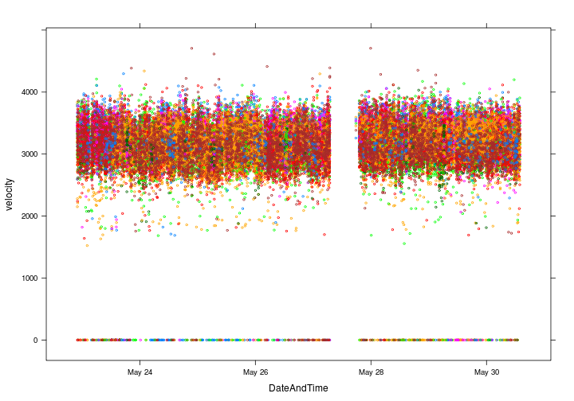

What fraction of log velocities are good (2200 < *v* < 4000 m/s), null (*v* = 0) and bad?

```
##
##      bad     good     null
## 0.003243 0.986264 0.010493
```

99% good!

todo: plot these fractions through time.

## Stem Sonics: Foxtrot v SWIPC database

Foxtrot stem length vs database stem length:

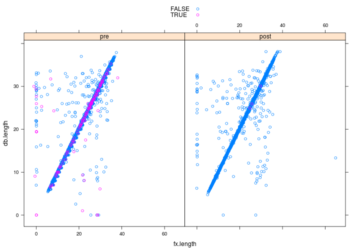

Pre = before 23/5/2014, Post = after 23/5/2014

Are the stem velocities being written on foxtrot the same as those being inserted into the database?

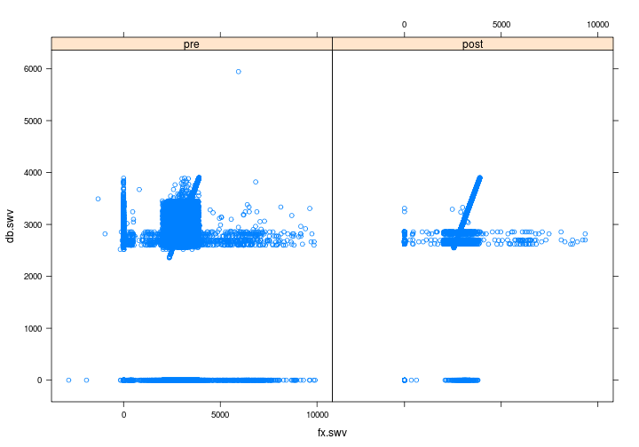

The 'post' fix matchup much improved over the 'pre' fix situation, but some oddities remain.

Why do some non-zero foxtrot velocities get written to the database as swv=0?

Where do the horizontal stripes come from? The foxtrot velocity is reasonable, but for some reason they are being assigned a default velocity? Maybe they have low confidence? No. Maybe they have weird lengths? No.

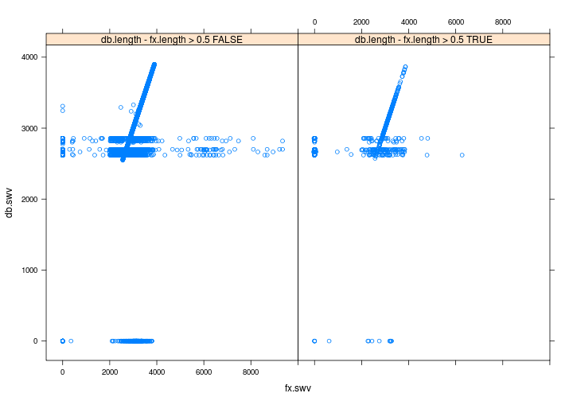

The foxtrot data still contains multiple records for the same stem, but after 2014-04-28 they are much fewer (15 dups from 25564 stems). All are consecutive. All have vel=0 for the second entry. Some have the same length for both records, but some do not e.g. from `Week15_15.txt`

```
StemID  Date      Time (H:M:S)  Velocity (m/s)  Density Length (m)  Confidence F (%)    Confidence P
3096    14/05/14    11:58:22        3060              458       23.57         98.4              1.25
3096      14/05/14  11:58:30        0                 0       -0.16       0.0                 0.00
:
6565    16/05/14    10:30:18        3249              479       24.94         96.5              2.53
6565      16/05/14  10:51:38        0                 0       24.94       0.0                 0.00
```

Do the duplicate stem velocity records turn up in the SWIPC db?

```
ID      DateAndTime             stemNumber  stemLength  stemVelocity
1364387 2014-05-14 12:02:13.893 3096          23.78       0
1364388 2014-05-14 12:02:20.460 3096          23.78       0
1364389 2014-05-14 12:02:36.970 3096          23.78       0
1364390 2014-05-14 12:02:45.947 3096          23.78       0
:
1382092 2014-05-16 10:32:46.957 6565          25.348        3246
1382093 2014-05-16 10:32:50.717 6565          25.348        3246
1382094 2014-05-16 10:32:56.770 6565          25.348        3246
1382095 2014-05-16 10:33:02.070 6565          25.348        3246
```

All logs from stems with duplicate foxtrot records look to have the same stemLength and stemVelocity. The lengths in the database and on foxtrot are similar, but in one case the velocity in the databse is 0 and in the other its about right.

Other curiosities:

- how come sometimes stemLength=0 in the SWIPC database? what circumstances will cause this to occur?
- why do some stems with a 4-digit number not appear in the foxtrot txt files? e.g. stemNumber=9379, 2014-05-25

## Default Stem SWV

When a good sonic value is available for a stem, then: (a) the stem is assigned a 4-digit stem number (b) the measured tem SWV is written to the SWIPC database

When no good stem sonic result is available: (a) the stem gets assigned a 5-digit stem number (b) a default value for the stem velocity is assigned based on where the stem came from and this value is written to the SWIPC database

If the above is correct then:

Why do so many of the 4-digit stems (i.e. stems with good meausred SWV) seem to be being assigned default SWV's?

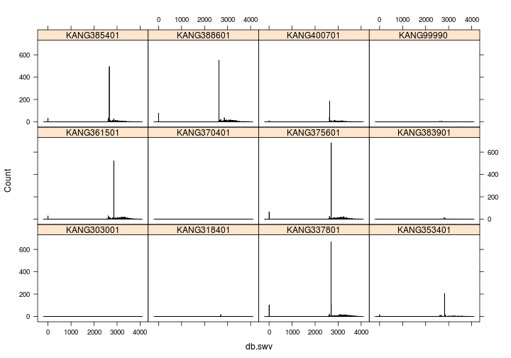

Why, as shown in the next plot, do stems from the same 'forest' with no good SWV measured not all have the same assigned SWV?

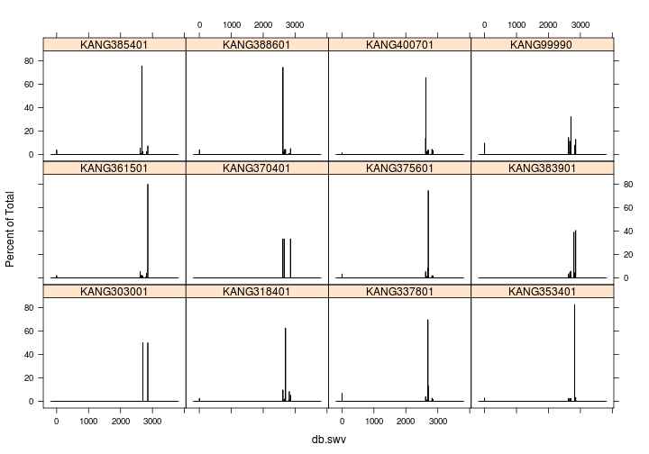

How do any of the 5-digit stems get random post-PLC velocities?

Here's a list of the default SWV values used for different forests (based on 5-digit stem SWV's in the SWIPC database):

```
## $` KANG385401 `
##  [1]    0 2620 2629 2665 2692 2701 2756 2801 2810 2819 2856 3010 3083 3628
##
## $` KANG388601 `
##  [1]    0 2620 2629 2647 2665 2692 2701 2801 2819 2856 2892 2965 3010 3137
##
## $` KANG99990  `
## [1]    0 2620 2629 2665 2692 2701 2819 2856
##
## $` KANG375601 `
##  [1]    0 2620 2629 2665 2692 2701 2801 2819 2856 2947 3010 3165 3174 3219
## [15] 3246 3319 3337 3373 3482
##
## $` KANG361501 `
##  [1]    0 2620 2629 2665 2692 2701 2801 2819 2856 2901 2928 3137 3264
##
## $` KANG337801 `
##  [1]    0 2620 2629 2665 2692 2701 2801 2819 2856 2883 2892 2938 3065 3183
## [15] 3591 3610 3619
##
## $` KANG400701 `
##  [1]    0 2620 2629 2665 2692 2701 2801 2819 2856 2883 3001 3155
##
## $` KANG353401 `
##  [1]    0 2620 2629 2665 2692 2701 2819 2856 3246 3355
##
## $` KANG383901 `
## [1] 2620 2629 2665 2692 2701 2801 2819 2856
##
## $` KANG318401 `
## [1]    0 2620 2629 2665 2692 2701 2801 2819 2856
##
## $` KANG370401 `
## [1] 2620 2665 2856
##
## $` KANG303001 `
## [1] 2701 2856
```

Is the default stem velocity (based on forest??) better than just using the mean velocity? or the velocity of the last 20 well struck stems or...

## Duplicate Log Records

Are there still duplicate log records in the SWIPC database?

```sql
/* find stemID's of stems with duplicate logs */
select top 10
  l1.stemID,
  l1.ID,
  l2.ID,
  l1.DateAndTime
from
  phase2 as l1,
  phase2 as l2
where
  l1.stemID=l2.stemID
  and l1.Startpos=l2.Startpos
  and l1.ID<l2.ID
order by
  l1.ID desc
```

Yes there are, e.g.

```
ID      DateAndTime             stemNumber  LogNumber   velocity    SED LED Startpos    EndPos  LogLength
1471836 2014-05-27 04:35:40.027 1698          3         3010        343 446 4104    8003    3900
1471837 2014-05-27 04:35:44.770 1698          3         3021        343 446 4104    8003    3900
1471838 2014-05-27 04:35:50.607 1698          4         3052        343 404 8003    14104   6100
1471839 2014-05-27 04:35:55.050 1698          5         2886        301 358 14104   19004   4900
1471840 2014-05-27 04:36:00.963 1698          7         2858        218 299 19460   25460   6000
```

What causes these duplicates? Why are the velocities different but everything else the same?

## Stem vs Log Velocity

SWIPC stem SWV vs individual log velocities:

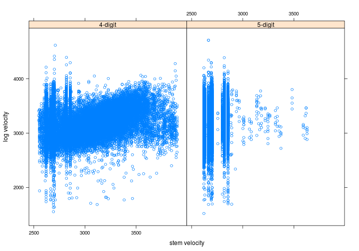

Stem velocity vs average log velocity

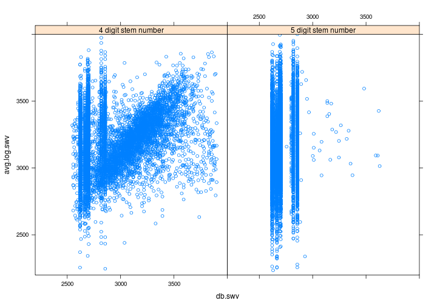

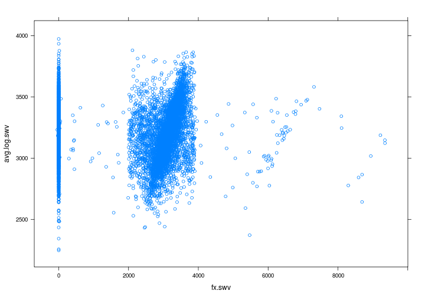

Better, but still a lot of noise...

Foxtrot velocity slightly better than SWIPC db?

What produces the vertical stripes? Presumably they come from some sort of default stem velocity.

In the fx.swv vs avg.log.swv plot, there are a handful of stem velocities that look to be twice (or even three times) the actual velocity. This could no doubt be fixed in the stem tool software (but is it worth bothering?)

Does the stem-to-avg-log swv correlation improve if poorly represented stems are not considered?

1. is the lfrac stuff sane?

```
##
## FALSE  TRUE
## 18446     6
```

```
##
## FALSE  TRUE
## 18431    21
```

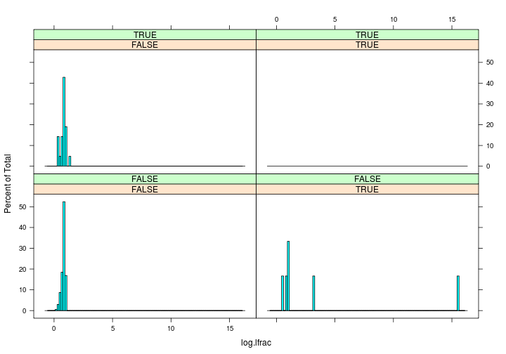

```
## [1] 1
```

```
##       stemID nlogs stemNumber       forest first.log.database.time length
## 2053  337728     2       7636  KANG375601      2014-05-24 16:15:15  9.252
## 6770  384528     6        487  KANG388601      2014-05-26 11:25:10 32.166
## 16411 432783     2      18161  KANG361501      2014-05-30 06:25:38 10.402
##       silly.length has.dupl.logs log.lfrac db.volume db.length db.swv
## 2053         FALSE         FALSE    0.9998      1.54     9.252   2701
## 6770         FALSE         FALSE    1.0000      1.97    32.166   3283
## 16411        FALSE         FALSE    0.9998      1.59    10.402   2856
##       nlogs.good.swv log.lfrac.good.swv avg.log.swv stemNumberDigits
## 2053               2             0.9998        3320                4
## 6770               6             1.0000        3308                4
## 16411              2             0.9998        3100                5
##       fx.swv fx.length
## 2053    3385      9.16
## 6770    3287     31.90
## 16411     NA        NA
```

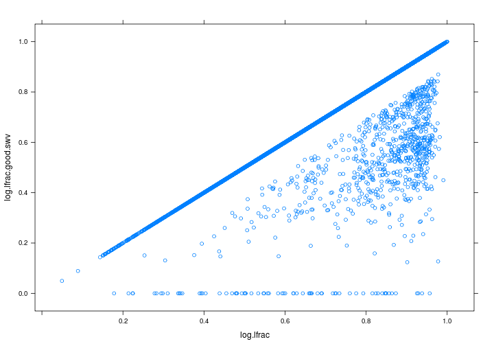

```
##       stemID nlogs stemNumber       forest first.log.database.time length
## 2053  337728     2       7636  KANG375601      2014-05-24 16:15:15  9.252
## 6770  384528     6        487  KANG388601      2014-05-26 11:25:10 32.166
## 16411 432783     2      18161  KANG361501      2014-05-30 06:25:38 10.402
##       silly.length has.dupl.logs log.lfrac db.volume db.length db.swv
## 2053         FALSE         FALSE    0.9998      1.54     9.252   2701
## 6770         FALSE         FALSE    1.0000      1.97    32.166   3283
## 16411        FALSE         FALSE    0.9998      1.59    10.402   2856
##       nlogs.good.swv log.lfrac.good.swv avg.log.swv stemNumberDigits
## 2053               2             0.9998        3320                4
## 6770               6             1.0000        3308                4
## 16411              2             0.9998        3100                5
##       fx.swv fx.length
## 2053    3385      9.16
## 6770    3287     31.90
## 16411     NA        NA
```

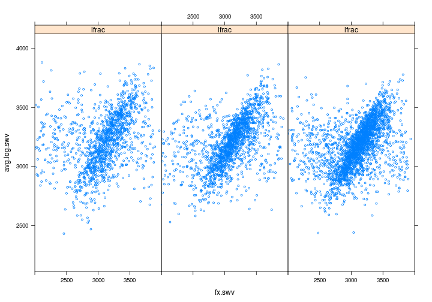

```
##   cut(S$log.lfrac, c(0, 0.7, 0.85, 0.92, 1))    n      cor
## 1                                    (0,0.7] 3951  0.04684
## 2                                 (0.7,0.85] 5068  0.07947
## 3                                (0.85,0.92] 4913  0.07509
## 4                                   (0.92,1] 4445  0.08284
## 5                                       <NA>    6 -0.15890
```

Relationship barely improves as more of the stem is recovered as logs.

Does the difference between fx.length and db.length influence correlation?

```
##    Min. 1st Qu.  Median    Mean 3rd Qu.    Max.    NA's
##       0       0       0       1       0      52   10125
```

```
##       stemID nlogs stemNumber       forest first.log.database.time length
## 808   325810     6       8806  KANG99990       2014-05-25 11:48:36  32.19
## 2609  343249     5       1026  KANG375601      2014-05-26 18:36:25  30.69
## 8704  402692     1       7844  KANG337801      2014-05-24 18:21:18  13.33
## 12650 429021     5       2991  KANG388601      2014-05-28 11:28:30  32.68
## 15594 431966     5       4070  KANG375601      2014-05-29 01:18:46  31.93
## 17738 434110     6       6044  KANG361501      2014-05-30 05:11:43  32.40
##       silly.length has.dupl.logs log.lfrac db.volume db.length db.swv
## 808          FALSE         FALSE    0.9663      4.19     32.19   2856
## 2609         FALSE         FALSE    0.8195      3.53     30.69   2701
## 8704         FALSE         FALSE    0.4427      4.46     13.33   2692
## 12650        FALSE         FALSE    0.7771      3.10     32.68   2620
## 15594        FALSE         FALSE    0.8362      2.26     31.93   2701
## 17738        FALSE         FALSE    0.8472      2.68     32.40   2856
##       nlogs.good.swv log.lfrac.good.swv avg.log.swv stemNumberDigits
## 808                6             0.9663        3333                4
## 2609               5             0.8195        2708                4
## 8704               1             0.4427        2836                4
## 12650              5             0.7771        3239                4
## 15594              5             0.8362        3306                4
## 17738              6             0.8472        3184                4
##       fx.swv fx.length
## 808        0      0.20
## 2609      22      0.05
## 8704       0     64.82
## 12650     14      0.05
## 15594      0      0.09
## 17738    -29     -0.08
```

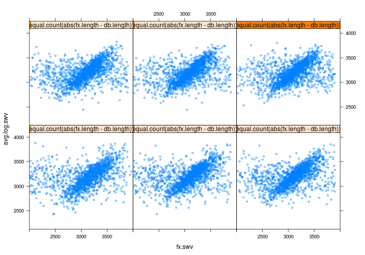

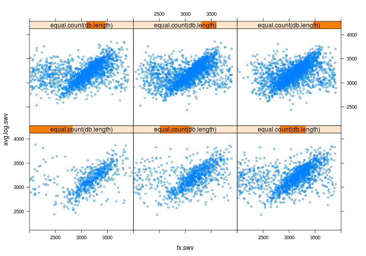

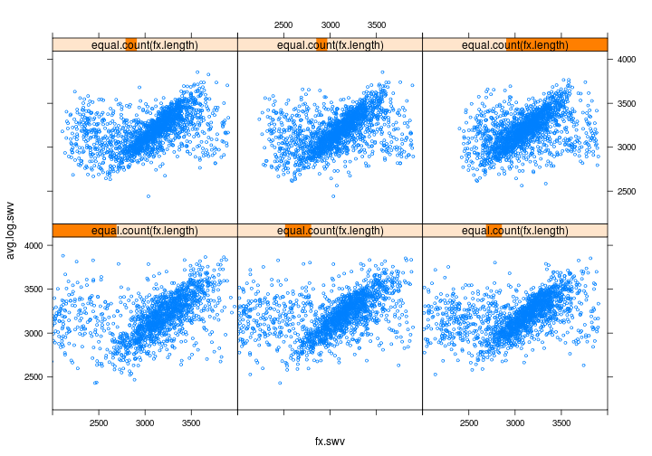

Nothing obvious.

## Hunting Bad Uns

Lets go take a detailed look at a handful of the random data points:

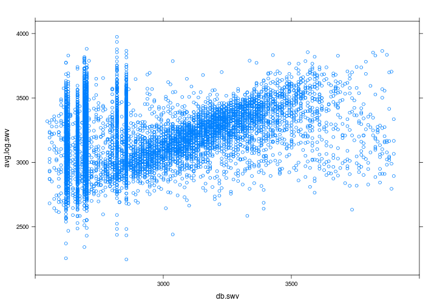

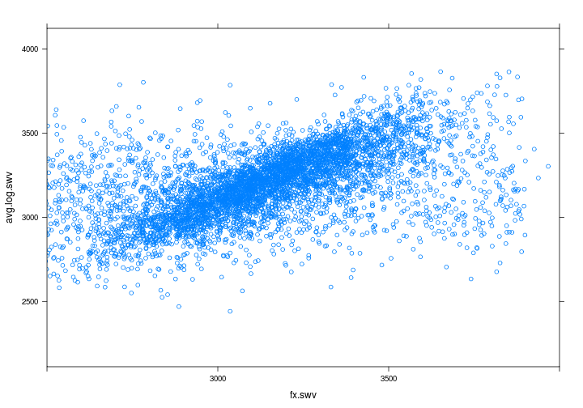

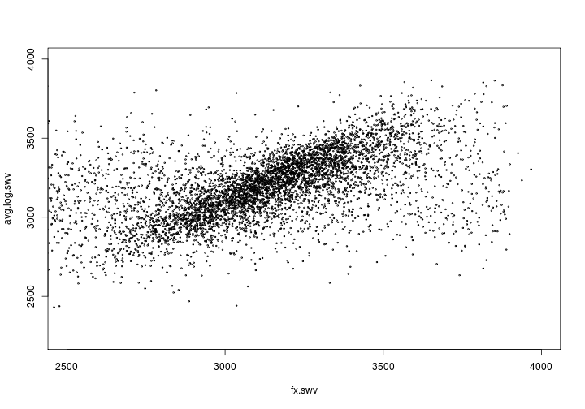

```
## integer(0)
```

```sql
select * from phase2 where stemID=366054;
select * from foxtrot where abs(datediff(minute,DateAndTime,(select DateAndTime from foxtrot where stemNumber=9727 and abs(datediff(day,DateAndTime,'2014-05-26'))<5)))<5

select * from phase2 where abs(datediff(minute,DateAndTime,(select top 1 DateAndTime from phase2 where stemID=387780)))<3 order by DateAndTime;
select * from foxtrot where abs(datediff(minute,DateAndTime,(select DateAndTime from foxtrot where stemNumber=928 and abs(datediff(day,DateAndTime,'2014-05-26'))<5)))<5
/* the db.swv for this stem is same as several previous stems */

select * from phase2 where abs(datediff(minute,DateAndTime,(select top 1 DateAndTime from phase2 where stemID=336135)))<3 order by DateAndTime;
select * from foxtrot where abs(datediff(minute,DateAndTime,(select DateAndTime from foxtrot where
stemNumber=9380
and abs(datediff(day,DateAndTime,'2014-05-25'))<5)))<5
/* perhaps the fx.swv here is actually for the previuos stem (9379) which somehow never makes it into the fx txt file? */

select * from phase2 where abs(datediff(minute,DateAndTime,(select top 1 DateAndTime from phase2 where stemID=413695)))<3 order by DateAndTime;
select * from foxtrot where abs(datediff(minute,DateAndTime,(select DateAndTime from foxtrot where
stemNumber=1841
and abs(datediff(day,DateAndTime,'2014-05-27'))<5)))<5
/* nothing obviously odd */

select * from phase2 where abs(datediff(minute,DateAndTime,(select top 1 DateAndTime from phase2 where stemID=422260)))<3 order by DateAndTime;
select * from foxtrot where abs(datediff(minute,DateAndTime,(select DateAndTime from foxtrot where
stemNumber=6687
and abs(datediff(day,DateAndTime,'2014-05-24'))<5)))<5

select * from phase2 where abs(datediff(minute,DateAndTime,(select top 1 DateAndTime from phase2 where stemID=405019)))<3 order by DateAndTime;
select * from foxtrot where abs(datediff(minute,DateAndTime,(select DateAndTime from foxtrot where
stemNumber=6286
and abs(datediff(day,DateAndTime,'2014-05-23'))<5)))<5
```

Not much joy.

## Datum Classification

Consider a model for the sonic data that involves two processes:

1. a linear relationship between stem swv and average log swv, but with a large amount of noise coming from
1. measurement error
2. not having all of the stem represented by logs
3. physical differences between the resonance of the whole stem and the average of its parts
2. a process for which stem and average log velocities are uncorrelated, but whose pdf matches the marginal distribution.

Process 2 might originate in the stem instrument (hardware or software) or might result from a stem tracking failure.

How can we classify data points according to which of these processes they originated by?

### Ransac

Robustly fit a linear relationship using a RANSAC atype algorithm. Inliers belong to porcess 1, outliers to process 2.

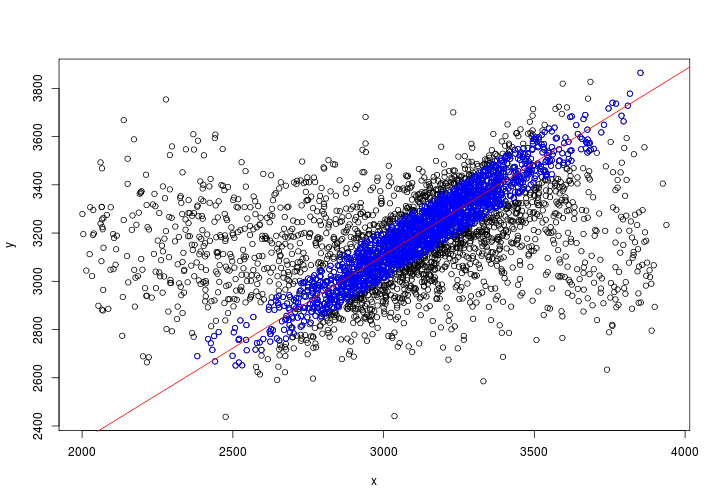

### Regression Mixtures

Lets try a mixture of regressions model:

```
## number of iterations= 61
```

```
## summary of regmixEM object:
##            comp 1      comp 2
## lambda   0.636682    0.363318
## sigma  105.548784  461.773126
## beta1  -77.847772 2436.528185
## beta2    1.006946    0.178309
## loglik at estimate:  -24912
```

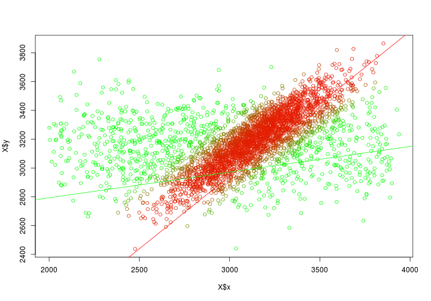

This model suggests ~35% of time the stem sonic velocity is essentially uncorrelated with the average log sonic speed.

This mixture regression modelling works well enough that it can be used from here on to quantify improvements.

Lets use the classification from the regression mixture model to colour a pairs plot

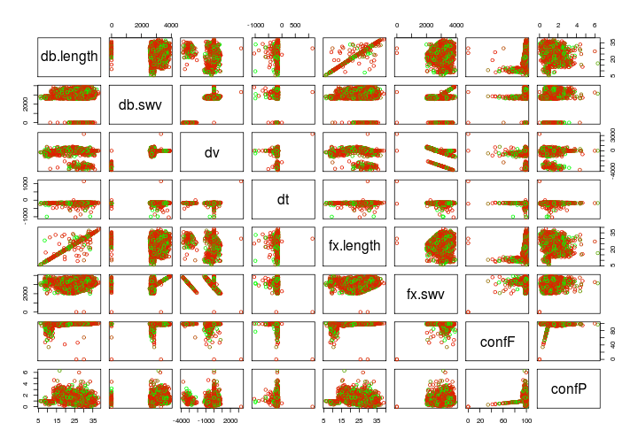

Nothing useful appears.

## USNR

What fraction of the stems have binfiles written using the wrong ID?

```sql
select
  count(*)
from (
  select
    stemID,
    min(DateAndTime) as DateAndTime,
    max(stemNumber) as stemNumber,
    min(m_fail) as m_fail
  from
    phase2
  where
    (m_fail is not null or m_nslices is not null)
    and DateAndTime>'2014-05-01'
  group by
    stemID
  ) as tmp
 where
   m_fail like '%binfile does not%'
```

40%!

## Things That Could Be Done

- Fix whatever casues the foxtrot log file to record multiple records for some stems
- insert both stem swv from foxtrot (unmodified) and stem swv post PLC (the same as going to the optimizer) into the SWIPC database.
- capture a large number of time series from foxtrot and reanalyse for odd results - if reanalysis better correlates with log avg then less reason to chase mismatches (need KPP sonics Sytem password)
- collect a larger hitman v KPP stem sonic dataset to further investigate if the random noise originates in the stem tool (hardwar or software), and to clarify if the tool needs to be completely rebuilt or just re-engineered to sucessfully hit a higher % of stems.
- why is the year part of the WeekXX_YY.txt log files on foxtrot greater than the current year by 1? (i.e. log files from 2014 are named WeekXX_15.txt)
- Assign a unique stemID at time each stem processed (rather than retrospectively via XXX.py) - actually this must be being done already in the echo db
- Rationalize the various data repositories (echo db, CUR_STEM_DET.dbf, bucketCaliper.csv, SWIPC db, ...) and automate reporting

from `questions.md`:

- Compare the stem-to-log velocity model in use in the bucker with other implementations
- Check that the model used to predict log velocity from stem velocity would not benefit from incorporating more data. Investigate continually updating the model based on data collected, would this improve the bucking optimiser?
- What are the log velocity grade limits?
- Where does the 'Forest' information come from? Is it reliable?
- Understand the differences between final log LED/SED and LED/SED from the bin files. Is this solely due to error in the final log diameter measurement? Ifso, what's a reasonable tolerance (50mm tolerance rejects >40% of logs)
- Record full grade numbers rather than 3char codes (e.g. S30R rather than DS3)